# Homework 7

Yiming Gao (NetID: yimingg2)

2017/3/28

# Exercise 1

For this assignment, we will use the `College` data from the `ISLR` package. Familiarize yourself with this dataset before performing analyses. We will attempt to predict the `Outstate` variable.

```r
set.seed(42)
library(caret)
library(ISLR)
index = createDataPartition(College$Outstate, p = 0.80, list = FALSE)
college_trn = College[index, ]
college_tst = College[-index, ]
```

Train a total of **six** models using five-fold cross validation. First I set up some helper functions for further discussion.

```r
uin = 650379994
set.seed(uin)
cv_5 = trainControl(method = "cv", number = 5) # five-fold cross validation

# accuracy function
accuracy = function(actual, predicted) {
  mean(actual == predicted)
}

# rmse function
rmse = function(actual, predicted) {
  sqrt(mean((actual - predicted) ^ 2))
}

get_rmse = function(model, data, response) {
  rmse(actual = data[, response],
       predicted = predict(model, data))
}

# extract the row with the best tuning parameters
get_best_result = function(caret_fit) {
  best_result = caret_fit$results[as.numeric(rownames(caret_fit$bestTune)), ]
  rownames(best_result) = NULL
  best_result
}
```

1. An additive linear model.

```r
model1 = train(
  Outstate ~ ., data = college_trn,
  method = "lm",
  trControl = cv_5
)
# cv rmse
model1_cv_rmse = model1$results$RMSE

# test rmse
model1_tst_rmse = get_rmse(model1, data = college_tst, response = "Outstate")
```

2. An elastic net model using additive predictors. Use a `tuneLength` of `10`.

```r
model2_search = train(
  Outstate ~ ., data = college_trn,
  method = "glmnet",
  trControl = cv_5,
  tuneLength = 10 # use a larger tuning grid, search 10 alpha values and 10 lambda valuas for each
)

# get best model
model2 = get_best_result(model2_search)

# cv rmse
model2_cv_rmse = model2$RMSE

# test rmse
# by default, the train function chooses the model with the largest performance value (or smallest, for mean squared error in regression models
model2_tst_rmse = get_rmse(model2_search, data = college_tst, response = "Outstate")
```

3. An elastic net model that also uses all two-way interactions. Use a `tuneLength` of `10`.

```r
# consider interactions
model3_search = train(
  Outstate ~ . ^ 2, data = college_trn,
  method = "glmnet",
  trControl = cv_5,
  tuneLength = 10
)

# get best model
model3 = get_best_result(model3_search)

# cv rmse
model3_cv_rmse = model3$RMSE

# test rmse
model3_tst_rmse = get_rmse(model3_search, data = college_tst, response = "Outstate")
```

4. A well-tuned KNN model.

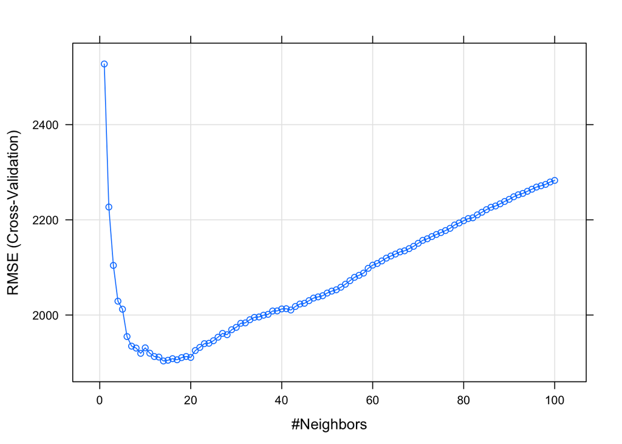

```r
# search many k
model4_search = train(
  Outstate ~ ., data = college_trn,
  method = "knn",
  tuneGrid = expand.grid(k = seq(1, 100, by = 1)),
  trControl = cv_5,
  preProcess = c("center", "scale")
)

plot(model4_search)
```

```r
# get best k
model4 = get_best_result(model4_search)

# cv rmse
model4_cv_rmse = model4$RMSE

# test rmse
model4_tst_rmse = get_rmse(model4_search, data = college_tst, response = "Outstate")
```

5. A well-tuned KNN model that also uses all two-way interactions. (Should this work?)

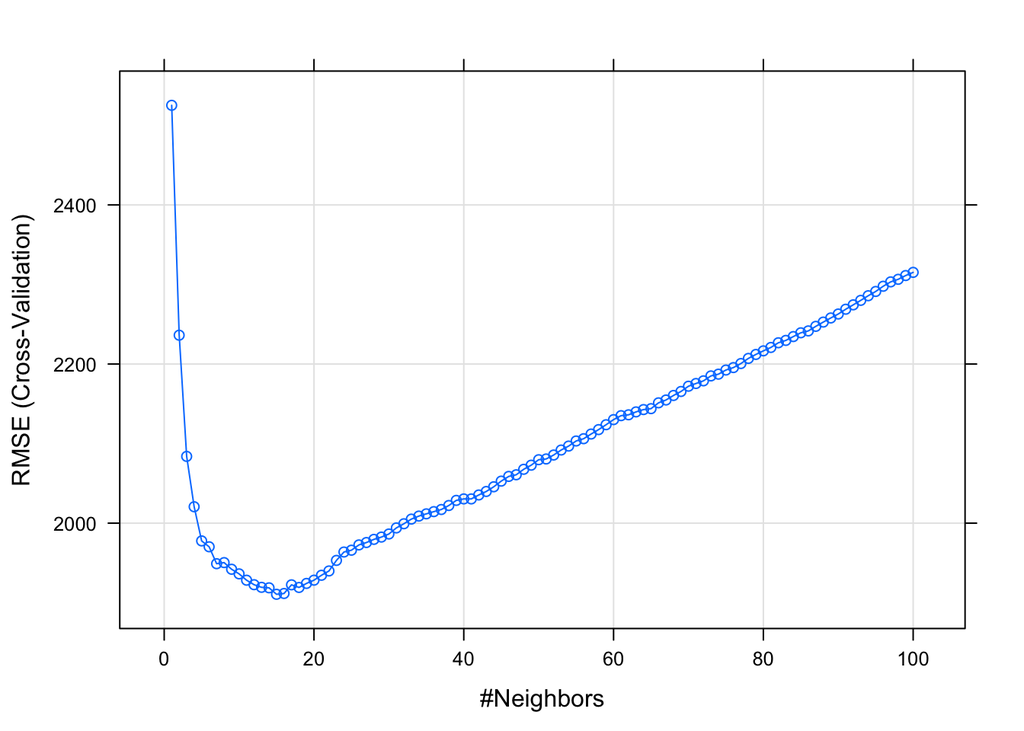

```r
model5_search = train(
  Outstate ~ . ^ 2, data = college_trn,
  method = "knn",
  tuneGrid = expand.grid(k = seq(1, 100, by = 1)),
  trControl = cv_5,
  preProcess = c("center", "scale")
)

plot(model5_search)
```

```r
# get best k
model5 = get_best_result(model5_search)

# cv rmse
model5_cv_rmse = model5$RMSE

# test rmse
model5_tst_rmse = get_rmse(model5_search, data = college_tst, response = "Outstate")
```

6. A well-tuned GAM, trained using `method = gamSpline` with `caret`.

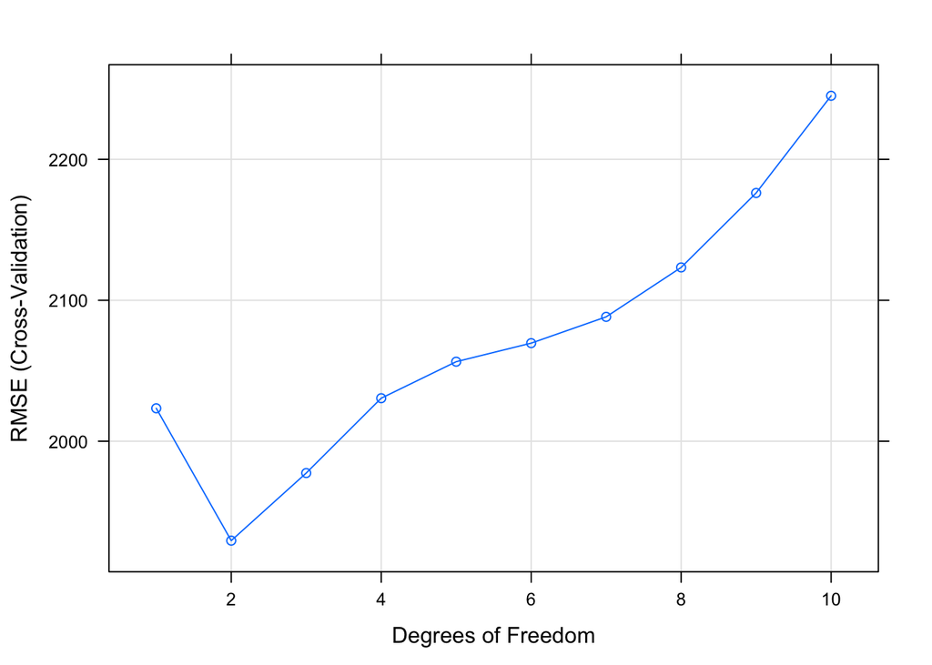

```r
# GAM
model6_search = train(
  Outstate ~ ., data = college_trn,
  method = "gamSpline",
  tuneGrid = expand.grid(df = 1:10),
  trControl = cv_5
)

plot(model6_search)
```

```r
# get best k
model6 = get_best_result(model6_search)

# cv rmse
model6_cv_rmse = model6$RMSE

# test rmse
model6_tst_rmse = get_rmse(model6_search, data = college_tst, response = "Outstate")
```

We can see a U-shaped line, which means the GAM is well-tuned.

| Method | Parameter | Parameter Value | CV RMSE | Test RMSE |
| --- | --- | --- | --- | --- |
| Additive Linear Model | NA | NA | 2020.391 | 2004.065 |
| Elastic net | `alpha` | 0.1 | 2005.630 | 2027.418 |
| Elastic net with interactions | `alpha` | 0.1 | 1865.982 | 1698.490 |
| KNN | `k` | 14 | 1903.491 | 1959.809 |
| KNN with interactions | `k` | 15 | 1910.585 | 1917.296 |
| GAM | `df` | 2 | 1929.442 | 1832.115 |

Also answer the following:

- Create a table which reports CV and Test RMSE for each.
  - See above.
- Based on the table, which model do you prefer? Justify your answer.
  - I prefer the third model, i.e., the elastic net model using all two-way interactions with parameters $\alpha$ = 0.1 and $\lambda$ = 40.755.
- For both of the elastic net models, report the best tuning parameters from `caret`. For each, is this ridge, lasso, or somewhere in between? If in between, closer to which?
  - The best tuning parameter for elastic net model using additive predictors is $\alpha$ = 0.1. Since $\alpha$ is neither 0 nor 1 but closer to 0, it is closer to **ridge**.
  - The best tuning parameter for elastic net model that also uses all two-way interactions is $\alpha$ = 0.1. Since $\alpha$ is neither 0 nor 1 but closer to 0, it is closer to **ridge**.
- Did you scale the predictors when you used KNN? Should you have scaled the predictors when you used KNN?
  - I **scaled** the predictors to have 0 mean and unit variance when using KNN. In this particular case, I should have scaled them because variables are in different units or range, which may cause one variable dominate other variables in the distance measurements.
- Of the two KNN models which works better? Can you explain why?
  - They both give similar k, CV RMSE and Test RMSE. But in terms of simplicity, we may want a simpler model that is KNN without interactions.
- For both of the KNN models, plot the CV results against the tuning parameters. Does this plot verify that you used an appropriate tuning grid?
  - See above. We see that in both plots, the RMSE fall then rise, which indicates that we have checked a sufficient number of tuning parameters.
- For the GAM, plot the CV results against the tuning parameters. Does this plot verify that you used an appropriate tuning grid?
  - See above. We see the RMSE fall then rise, which indicates that we have checked a sufficient number of tuning parameters.
- What was the best tuning parameter for the GAMs? Does this suggest non-linearity?
  - The best tuning parameter for GAMs is degree of freedom = 2. GAM allows for flexible nonlinearities in several variables, but still retains the additive structure of linear models. So it does **NOT** imply non-linearity.

```r
College["University of Illinois - Urbana", ]$Outstate
```

```
## [1] 7560
```

- What year is this dataset from? What was out-of-state tuition at UIUC at that time?
  - Using `help()` function in R, we know this `College` dataset comes from 1995. The out-of-state tuition at UIUC at that time was 7560.

# Exercise 2

Use `Private` as the response variable. Fit Regularized Discriminant Analysis trained using five-fold cross-validation and a tuning length of `5` with `train()`.

```r
library(ggplot2)
set.seed(42)
cv_5 = trainControl(method = "cv", number = 5)
# make sure the response is factor
is.factor(college_trn$Private)
```

```
## [1] TRUE
```

First we verify that `Private` is a factor variable. Then we create RDA with grid search.

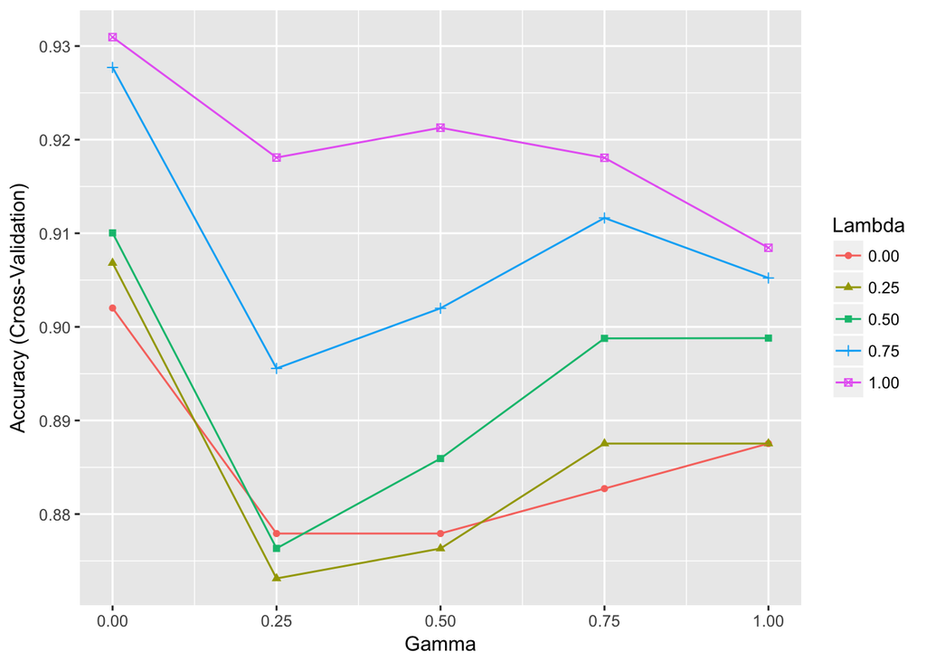

```r
# fit rda model
rda_search = train(
  Private ~ ., data = college_trn,
  method = "rda",
  trControl = cv_5,
  tuneLength = 5
)

ggplot(rda_search)
```

```r
# find the best tuning parameters
rda = get_best_result(rda_search)
```

We can clearly identify that the pink line with $\gamma=0$ and $\lambda=1$ has the highest cross-validated accuracy. Then we calculate its test accuracy.

```r
paste("gamma =", rda$gamma, ", lambda =", rda$lambda)
```

```
## [1] "gamma = 0 , lambda = 1"
```

```r
# CV-Accuracy
rda_cv_acc = rda$Accuracy

# test accuracy
rda_tst_acc = accuracy(actual = college_tst$Private, predicted = predict(rda_search, newdata = college_tst))

round(c(rda_cv_acc, rda_tst_acc), 3)
```

```
## [1] 0.931 0.948
```

The best tuning parameters are $\gamma$ = 0 and $\lambda$ = 1. The cross-validated accuracy is 0.931. We know that when $\gamma=0, \lambda=1$, it is **LDA** which uses a common covariance matrix. The test accuracy is 0.9481. The cross-validated and test accuracy are both high and there is not too much difference, which means our model predicts well in this case.